# Trade war between the U.S. and China: *What accounts for China's unprecedented growth?*

China's explosive economic power has been a concern for many Americans, as the U.S.'s massive trade deficit to China is in the hundreds of billions (USD) and continues to grow. U.S. President Donald J. Trump and Chinese President Xi Jinping are at odds, with both countries raising protective tariffs from 2018 onwards which seem to remove the conflict further from resolution. This clashing between the two economic powerhouses of the world casts uncertainty over the global economy at large. The following questions are relevant towards understanding this crisis:

## What is the extent of the difference between the U.S. and Chinese trade economies?

To answer this, we explore:

1. How has China's trade changed historically (1990-present) to its present state?
2. How has U.S. trade changed changed historically (1990-present) to its present state?

We will address these questions using the [World Development Indicators](https://www.kaggle.com/worldbank/world-development-indicators) dataset available from Kaggle.

First, we simplify and clean up our dataset for this specific inquiry.

```python
import pandas as pd
import numpy as np
import matplotlib.pyplot as plt
%matplotlib inline
```

This dataset is quite large.

```python
raw = pd.read_csv('./Indicators.csv')
raw.shape
```

```
(5656458, 6)
```

This is the type of dataset we are working with.

```python
raw.head(5)
```

|  | CountryName | CountryCode | IndicatorName | IndicatorCode | Year | Value |
| --- | --- | --- | --- | --- | --- | --- |
| 0 | Arab World | ARB | Adolescent fertility rate (births per 1,000 wo... | SP.ADO.TFRT | 1960 | 1.335609e+02 |
| 1 | Arab World | ARB | Age dependency ratio (% of working-age populat... | SP.POP.DPND | 1960 | 8.779760e+01 |
| 2 | Arab World | ARB | Age dependency ratio, old (% of working-age po... | SP.POP.DPND.OL | 1960 | 6.634579e+00 |
| 3 | Arab World | ARB | Age dependency ratio, young (% of working-age ... | SP.POP.DPND.YG | 1960 | 8.102333e+01 |
| 4 | Arab World | ARB | Arms exports (SIPRI trend indicator values) | MS.MIL.XPRT.KD | 1960 | 3.000000e+06 |

Since the dataset contains data on "regions" we don't need, let's delete all rows which refer to areas that aren't countries. We rely on help from this [datahub.io dataset](https://datahub.io/core/country-codes#data) which contains valid country codes.

```python
country_codes = pd.read_csv('./country-codes.csv')
country_codes = country_codes['ISO3166-1-Alpha-3']
countries_in_raw = pd.Series(raw['CountryCode'].unique().tolist())
countries_toDropFrom_raw = (list(set(countries_in_raw) - set(country_codes)))
raw = raw[~raw['CountryCode'].isin(countries_toDropFrom_raw)]
raw.head(5)
```

|  | CountryName | CountryCode | IndicatorName | IndicatorCode | Year | Value |
| --- | --- | --- | --- | --- | --- | --- |
| 3492 | Afghanistan | AFG | Adolescent fertility rate (births per 1,000 wo... | SP.ADO.TFRT | 1960 | 1.453210e+02 |
| 3493 | Afghanistan | AFG | Age dependency ratio (% of working-age populat... | SP.POP.DPND | 1960 | 8.171773e+01 |
| 3494 | Afghanistan | AFG | Age dependency ratio, old (% of working-age po... | SP.POP.DPND.OL | 1960 | 5.086254e+00 |
| 3495 | Afghanistan | AFG | Age dependency ratio, young (% of working-age ... | SP.POP.DPND.YG | 1960 | 7.663147e+01 |
| 3496 | Afghanistan | AFG | Arms imports (SIPRI trend indicator values) | MS.MIL.MPRT.KD | 1960 | 4.000000e+07 |

Note that we also made the dataset smaller and more manageable.

```python
raw.shape
```

```
(4827592, 6)
```

Moving on, since we are focusing on trade, let's try to find some indicators relating to trade in this dataset.

```python
indicators = pd.Series(raw['IndicatorName'].unique().tolist())
indicators[indicators.str.contains("Trade")]
```

```
109                               Trade (% of GDP)
228                  Trademark applications, total
231     Trademark applications, direct nonresident
232        Trademark applications, direct resident
1285                  Trade in services (% of GDP)
dtype: object
```

We don't want to focus on trade as a percentage of GDP since we'd lose specific dollar amounts. Let's try focusing on imports and exports.

```python
indicators[indicators.str.contains("Imports")]
```

```
51               Imports of goods and services (% of GDP)
52            Imports of goods and services (current LCU)
53            Imports of goods and services (current US$)
158     Imports of goods and services (constant 2005 US$)
159          Imports of goods and services (constant LCU)
293       Imports of goods and services (annual % growth)
1257     Imports of goods and services (BoP, current US$)
1258    Imports of goods, services and primary income ...
dtype: object
```

```python
indicators[indicators.str.contains("Exports")]
```

```
16               Exports of goods and services (% of GDP)
17            Exports of goods and services (current LCU)
18            Exports of goods and services (current US$)
120        Exports as a capacity to import (constant LCU)
121     Exports of goods and services (constant 2005 US$)
122          Exports of goods and services (constant LCU)
282       Exports of goods and services (annual % growth)
1250     Exports of goods and services (BoP, current US$)
1251    Exports of goods, services and primary income ...
dtype: object
```

For now, let's focus on "Imports/exports of goods and services (current USD)" for simplicity's sake, although the dataset offers such other indicators as "Merchandise imports (current USD)" with imports/exports in lowercase "i", "e".

Let's simplify our dataset with just the columns for country code, imports/exports of G&S, year, and value.

```python
stage0 = raw[['CountryCode','IndicatorName','Year','Value']]
ind_exp_filter = stage0['IndicatorName'].str.match('Exports of goods and services \(current US\$\)')
ind_imp_filter = stage0['IndicatorName'].str.match('Imports of goods and services \(current US\$\)')
year_filter = stage0['Year'] >= 1990
stage1 = stage0[(ind_exp_filter | ind_imp_filter) & year_filter]
stage1.head(5)
```

|  | CountryCode | IndicatorName | Year | Value |
| --- | --- | --- | --- | --- |
| 1896451 | ALB | Exports of goods and services (current US$) | 1990 | 3.125000e+08 |
| 1896543 | ALB | Imports of goods and services (current US$) | 1990 | 4.875000e+08 |
| 1896881 | DZA | Exports of goods and services (current US$) | 1990 | 1.454566e+10 |
| 1897042 | DZA | Imports of goods and services (current US$) | 1990 | 1.547220e+10 |
| 1897817 | AGO | Exports of goods and services (current US$) | 1990 | 3.342246e+09 |

Next, we check to see if there are any missing values.

```python
stage1.isnull().any()
```

```
CountryCode      False
IndicatorName    False
Year             False
Value            False
dtype: bool
```

```python
stage1.shape
```

```
(8726, 4)
```

```python
stage1.dropna(axis=0)
stage1.dropna(axis=1)
stage1.shape
```

```
(8726, 4)
```

No cells were dropped, so this confirms that there aren't any NULL or empty cells.

Next, we begin some preliminary analysis.

### Analyzing Chinese and US trade over time

First, let's focus our dataset on Chinese trade. We need to filter the country and also filter out which entries are Exports versus Imports.

```python
chn_data = stage1[stage1['CountryCode'].str.match('CHN')]
chn_data_exports = chn_data[chn_data['IndicatorName'].str.contains('Exports')]
chn_data_imports = chn_data[chn_data['IndicatorName'].str.contains('Imports')]
```

Let's take a look at the following plot.

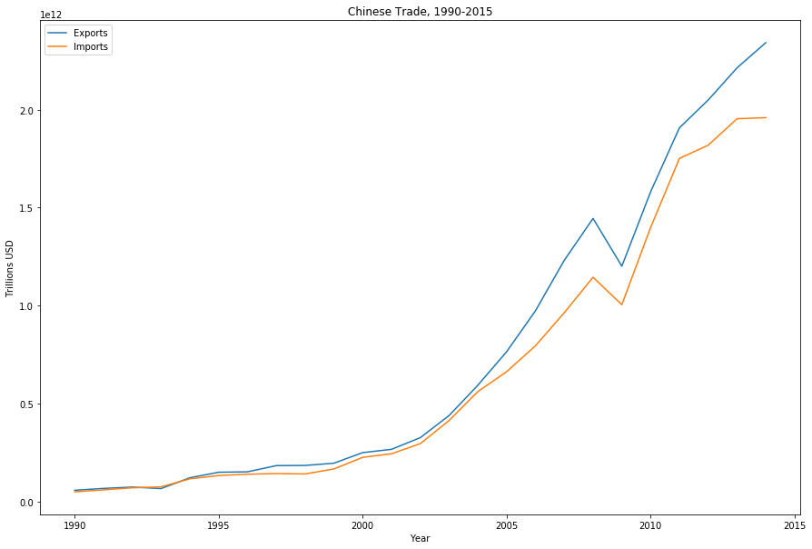

```python
plt.figure(figsize=(15,10))

plt.plot(chn_data_exports['Year'].values, chn_data_exports['Value'].values)
plt.plot(chn_data_imports['Year'].values, chn_data_imports['Value'].values)

plt.xlabel('Year')
plt.ylabel('Trillions USD')

plt.title('Chinese Trade, 1990-2015')

plt.legend(['Exports','Imports'])

plt.show()
```

We see an impressive upward trend for both Chinese imports and exports, but a clear positive trade surplus opening up after the early 2000s. This surplus persisted despite dips in both exports and imports around the 2008 financial crisis.

We can repeat this analysis for the US data to observe US trade over the same time frame.

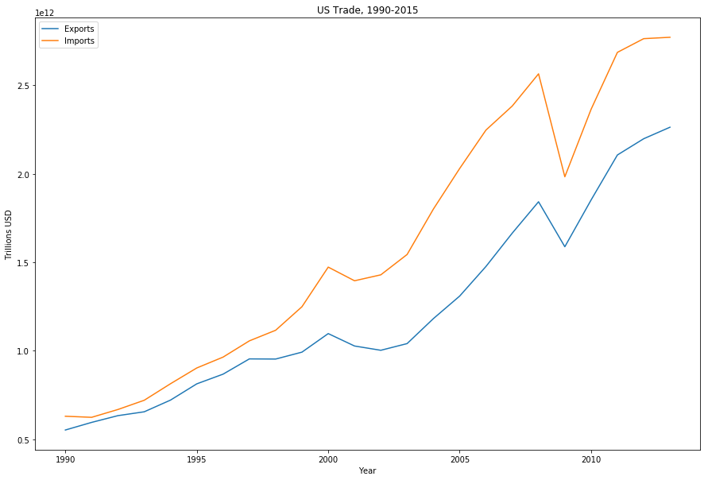

```python
usa_data = stage1[stage1['CountryCode'].str.match('USA')]
usa_data_exports = usa_data[usa_data['IndicatorName'].str.contains('Exports')]
usa_data_imports = usa_data[usa_data['IndicatorName'].str.contains('Imports')]

plt.figure(figsize=(15,10))

plt.plot(usa_data_exports['Year'].values, usa_data_exports['Value'].values)
plt.plot(usa_data_imports['Year'].values, usa_data_imports['Value'].values)

plt.xlabel('Year')
plt.ylabel('Trillions USD')

plt.title('US Trade, 1990-2015')

plt.legend(['Exports','Imports'])

plt.show()
```

Contrarily, we see a huge trade deficit opening up in the US from the 1990s onward. It persists through the 2008 recession, and in the present day the US trade deficit appears larger than the Chinese trade surplus.

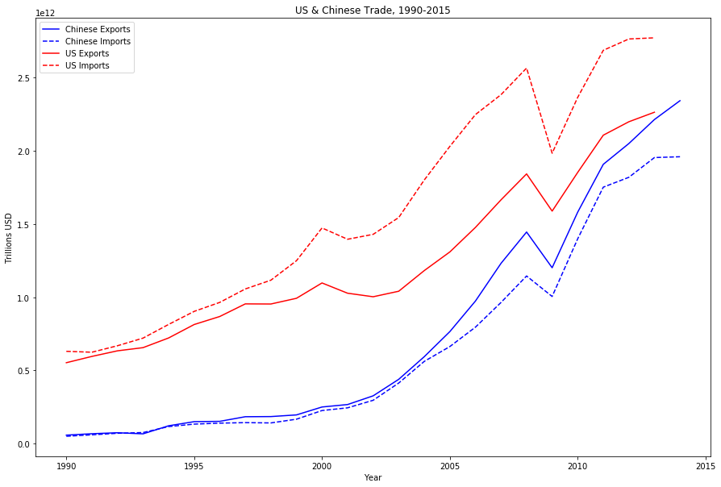

```python
plt.figure(figsize=(15,10))

plt.plot(chn_data_exports['Year'].values, chn_data_exports['Value'].values, color='b')
plt.plot(chn_data_imports['Year'].values, chn_data_imports['Value'].values, color='b', ls='dashed')
plt.plot(usa_data_exports['Year'].values, usa_data_exports['Value'].values, color='r')
plt.plot(usa_data_imports['Year'].values, usa_data_imports['Value'].values, color='r', ls='dashed')

plt.xlabel('Year')
plt.ylabel('Trillions USD')

plt.title('US & Chinese Trade, 1990-2015')

plt.legend(['Chinese Exports','Chinese Imports', 'US Exports', 'US Imports'])

plt.show()
```

Overlaying these two graphs, we can see the difference in how the two economies' trade have changed over a 25-year span.

All in all, the Chinese surplus has grown persistently, and Chinese exports and imports seem to both have increased in the post-2008 world. This suggests that the financial recession, in conjunction with other factors, seemed to catalyze, or at least encourage, further surplus growth.

## What explains the Chinese trade surplus?

Many economic indicators can be used to explain why the Chinese economy has entered into such a large surplus compared to the more developed US economy.

For this, we will split our analysis on exports and imports for both China and the US, and then compare the results.

### Chinese exports

We hypothesize that, in general, higher exports are a result of a **larger working population** and **higher education levels**, which both encourage productivity.

#### Workforce population & exports in China

Let's look for a relevant indicator for the Chinese workforce.

```python
indicators[indicators.str.contains("Labor")].tail(10)
```

```
848     Labor force participation rate, male (% of mal...
849     Labor force participation rate, total (% of to...
850     Labor force participation rate, total (% of to...
851          Labor force, female (% of total labor force)
852                                    Labor force, total
1193    Benefits incidence in poorest quintile (%) - A...
1195    Benefits incidence in poorest quintile (%) -Al...
1196                      Coverage (%) - All Labor Market
1198        Coverage (%) -All Social Protection and Labor
1330    Labor tax and contributions (% of commercial p...
dtype: object
```

"Labor force, total" seems to be of interest.

```python
ind_labor_filter = stage0['IndicatorName'].str.match('Labor force, total')
year_filter = stage0['Year'] >= 1990
stage2_exp_labor = stage0[ind_labor_filter & year_filter]
stage2_exp_labor.head(5)
```

|  | CountryCode | IndicatorName | Year | Value |
| --- | --- | --- | --- | --- |
| 1896194 | AFG | Labor force, total | 1990 | 3083498.0 |
| 1896573 | ALB | Labor force, total | 1990 | 1420090.0 |
| 1897086 | DZA | Labor force, total | 1990 | 6210711.0 |
| 1897958 | AGO | Labor force, total | 1990 | 4118283.0 |
| 1898822 | ARG | Labor force, total | 1990 | 13330838.0 |

To note any type of correlation with exports, we want to merge the above dataset with the previous datasets `chn_data_exports`, etc. which contained exports/imports data for countries.

First, we filter out just Chinese labor force data from `stage2_exp_labor`. Then, we do the merge on 'Year' and 'CountryCode'.

```python
stage2_exp_labor_chn = stage2_exp_labor[stage2_exp_labor['CountryCode'].str.match('CHN')]
stage2_exp_labor_chn = stage2_exp_labor_chn.merge(chn_data_exports, on=['CountryCode','Year'], how='inner')
stage2_exp_labor_chn = stage2_exp_labor_chn.drop(['IndicatorName_x','IndicatorName_y'], axis=1)
stage2_exp_labor_chn.rename(columns={'Value_x':'LaborForce','Value_y':'Exports'}, inplace=True)
stage2_exp_labor_chn.head(5)
```

|  | CountryCode | Year | LaborForce | Exports |
| --- | --- | --- | --- | --- |
| 0 | CHN | 1990 | 637334236.0 | 5.708987e+10 |
| 1 | CHN | 1991 | 645035504.0 | 6.667422e+10 |
| 2 | CHN | 1992 | 654895789.0 | 7.341130e+10 |
| 3 | CHN | 1993 | 665456534.0 | 6.588458e+10 |
| 4 | CHN | 1994 | 674951877.0 | 1.209208e+11 |

Nice. Let's look at how the Chinese labor force has changed over time. First, let's make sure we know the bounds for our data's years.

```python
stage2_exp_labor_chn['Year'].min()
```

```
1990
```

```python
stage2_exp_labor_chn['Year'].max()
```

```
2014
```

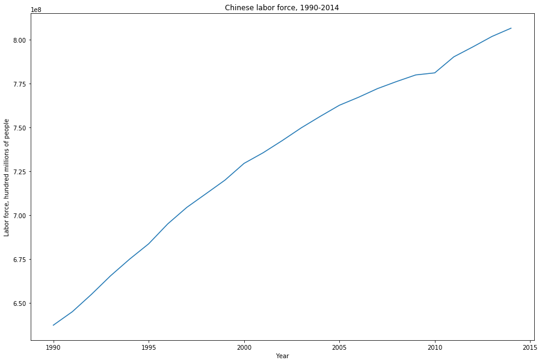

```python
plt.figure(figsize=(15,10))
plt.plot(stage2_exp_labor_chn['Year'].values, stage2_exp_labor_chn['LaborForce'])
plt.xlabel('Year')
plt.ylabel('Labor force, hundred millions of people')
plt.title('Chinese labor force, 1990-2014')
plt.show()
```

That's an impressive upward trend. Unlike the exports trend, this is more strongly linear.

Let's graph exports and labor force together on a scatter plot to see their relationship.

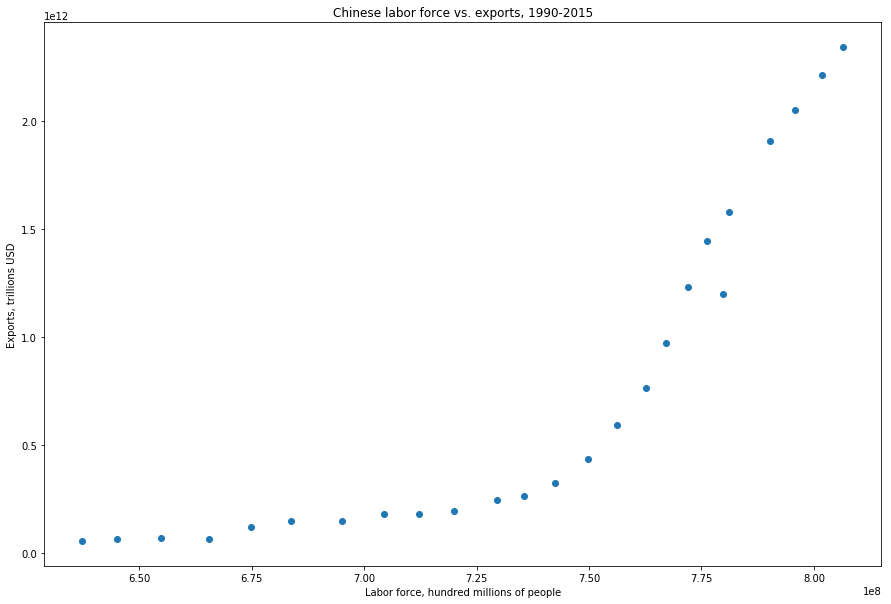

```python
plt.figure(figsize=(15,10))
plt.scatter(stage2_exp_labor_chn['LaborForce'].values, stage2_exp_labor_chn['Exports'].values)
plt.xlabel('Labor force, hundred millions of people')
plt.ylabel('Exports, trillions USD')
plt.title('Chinese labor force vs. exports, 1990-2015')
plt.show()
```

```python
stage2_exp_labor_chn.corr()
```

|  | Year | LaborForce | Exports |
| --- | --- | --- | --- |
| Year | 1.000000 | 0.988756 | 0.924720 |
| LaborForce | 0.988756 | 1.000000 | 0.861344 |
| Exports | 0.924720 | 0.861344 | 1.000000 |

#### Education & exports in China

Now, let's think about how exports relate to markers of education.

```python
indicators[indicators.str.contains('education')].shape
```

```
(80,)
```

```python
indicators[indicators.str.contains('education')].head(5)
```

```
347    Adjusted savings: education expenditure (% of ...
348    Adjusted savings: education expenditure (curre...
360    Enrolment in primary education, both sexes (nu...
361    Enrolment in secondary education, both sexes (...
395    Official entrance age to lower secondary educa...
dtype: object
```

There are a lot (80) of indicators listed here, but not all of them have much data for China. We tried exploring "Labor force with secondary education" and "Adult literacy rate," but there was not much data available from 1990 onwards.

After some trial-and-error to find out which indicators have robust datasets for China, "Enrolment in secondary education, both sexes" seems interesting.

Let's repeat the analysis we did for the Chinese labor force.

```python
ind_edu_filter = stage0['IndicatorName'].str.contains('Enrolment in secondary education, both')
year_filter = stage0['Year'] >= 1990
stage2_exp_edu = stage0[ind_edu_filter & year_filter]

stage2_exp_edu_chn = stage2_exp_edu[stage2_exp_edu['CountryCode'].str.match('CHN')]
stage2_exp_edu_chn = stage2_exp_edu_chn.merge(chn_data_exports, on=['CountryCode','Year'], how='inner')
stage2_exp_edu_chn = stage2_exp_edu_chn.drop(['IndicatorName_x','IndicatorName_y'], axis=1)
stage2_exp_edu_chn.rename(columns={'Value_x':'SecEdEnrollment','Value_y':'Exports'}, inplace=True)
stage2_exp_edu_chn.head(5)
```

|  | CountryCode | Year | SecEdEnrollment | Exports |
| --- | --- | --- | --- | --- |
| 0 | CHN | 1990 | 51799200.0 | 5.708987e+10 |
| 1 | CHN | 1991 | 52385600.0 | 6.667422e+10 |
| 2 | CHN | 1992 | 53690000.0 | 7.341130e+10 |
| 3 | CHN | 1993 | 55100000.0 | 6.588458e+10 |
| 4 | CHN | 1994 | 55548100.0 | 1.209208e+11 |

Now, let's look at how the enrollment in secondary education has changed over time.

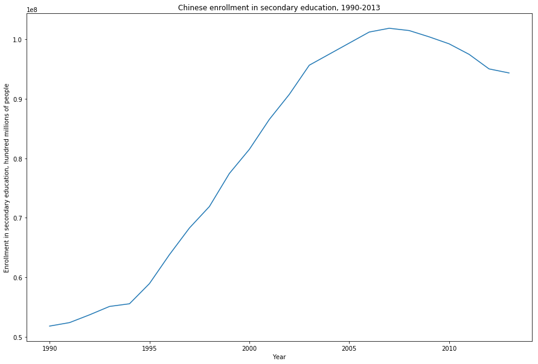

```python
plt.figure(figsize=(15,10))
plt.plot(stage2_exp_edu_chn['Year'].values, stage2_exp_edu_chn['SecEdEnrollment'])
plt.xlabel('Year')
plt.ylabel('Enrollment in secondary education, hundred millions of people')
plt.title('Chinese enrollment in secondary education, 1990-2013')
plt.show()
```

Strangely enough, the enrollment in secondary education seems to rise but then peak around 2006 before dipping slightly. The positive trend in secondary education enrollment is far less clear than the rise in the labor force.

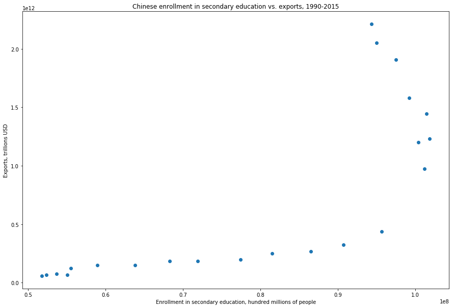

```python
plt.figure(figsize=(15,10))
plt.scatter(stage2_exp_edu_chn['SecEdEnrollment'].values, stage2_exp_edu_chn['Exports'].values)
plt.xlabel('Enrollment in secondary education, hundred millions of people')
plt.ylabel('Exports, trillions USD')
plt.title('Chinese enrollment in secondary education vs. exports, 1990-2015')
plt.show()
```

```python
stage2_exp_edu_chn.corr()
```

|  | Year | SecEdEnrollment | Exports |
| --- | --- | --- | --- |
| Year | 1.000000 | 0.934094 | 0.925607 |
| SecEdEnrollment | 0.934094 | 1.000000 | 0.761521 |
| Exports | 0.925607 | 0.761521 | 1.000000 |

All in all, the change in labor force seems to be a stronger predictor of trade exports than the enrollment in secondary education.

### US exports

Moving on, let's repeat these analyses for the US exports.

#### Workforce population & exports in the US

```python
stage2_exp_labor_usa = stage2_exp_labor[stage2_exp_labor['CountryCode'].str.match('USA')]
stage2_exp_labor_usa = stage2_exp_labor_usa.merge(usa_data_exports, on=['CountryCode','Year'], how='inner')
stage2_exp_labor_usa = stage2_exp_labor_usa.drop(['IndicatorName_x','IndicatorName_y'], axis=1)
stage2_exp_labor_usa.rename(columns={'Value_x':'LaborForce','Value_y':'Exports'}, inplace=True)
stage2_exp_labor_usa.head(5)
```

|  | CountryCode | Year | LaborForce | Exports |
| --- | --- | --- | --- | --- |
| 0 | USA | 1990 | 128187674.0 | 5.518740e+11 |
| 1 | USA | 1991 | 128775875.0 | 5.949320e+11 |
| 2 | USA | 1992 | 131047302.0 | 6.330530e+11 |
| 3 | USA | 1993 | 132506408.0 | 6.548000e+11 |
| 4 | USA | 1994 | 134973525.0 | 7.209390e+11 |

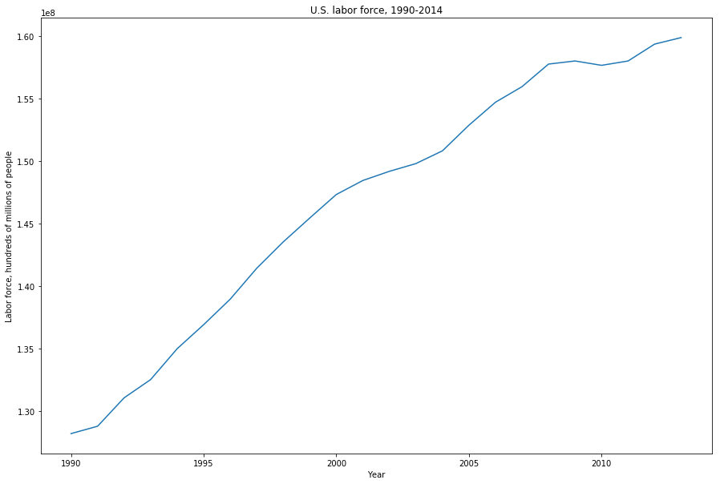

```python
plt.figure(figsize=(15,10))
plt.plot(stage2_exp_labor_usa['Year'].values, stage2_exp_labor_usa['LaborForce'])
plt.xlabel('Year')
plt.ylabel('Labor force, hundreds of millions of people')
plt.title('U.S. labor force, 1990-2014')
plt.show()
```

The labor force seems to have increased steadily. Note the dip in 2008, which is more clear in the US labor force than in the Chinese. The US's struggle to recover its post-recession economy is also reflected in fluctuations in the workforce from 2008 onwards.

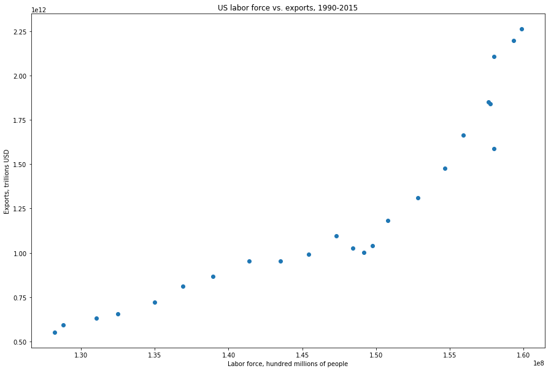

```python
plt.figure(figsize=(15,10))
plt.scatter(stage2_exp_labor_usa['LaborForce'].values, stage2_exp_labor_usa['Exports'].values)
plt.xlabel('Labor force, hundred millions of people')
plt.ylabel('Exports, trillions USD')
plt.title('US labor force vs. exports, 1990-2015')
plt.show()
```

```python
stage2_exp_labor_usa.corr()
```

|  | Year | LaborForce | Exports |
| --- | --- | --- | --- |
| Year | 1.000000 | 0.983454 | 0.959235 |
| LaborForce | 0.983454 | 1.000000 | 0.910342 |
| Exports | 0.959235 | 0.910342 | 1.000000 |

#### Education & exports in US

```python
stage2_exp_edu_usa = stage2_exp_edu[stage2_exp_edu['CountryCode'].str.match('USA')]
stage2_exp_edu_usa = stage2_exp_edu_usa.merge(usa_data_exports, on=['CountryCode','Year'], how='inner')
stage2_exp_edu_usa = stage2_exp_edu_usa.drop(['IndicatorName_x','IndicatorName_y'], axis=1)
stage2_exp_edu_usa.rename(columns={'Value_x':'SecEdEnrollment','Value_y':'Exports'}, inplace=True)
stage2_exp_edu_usa.head(5)
```

|  | CountryCode | Year | SecEdEnrollment | Exports |
| --- | --- | --- | --- | --- |
| 0 | USA | 1990 | 19276000.0 | 5.518740e+11 |
| 1 | USA | 1991 | 19270000.0 | 5.949320e+11 |
| 2 | USA | 1993 | 20516146.0 | 6.548000e+11 |
| 3 | USA | 1994 | 21055472.0 | 7.209390e+11 |
| 4 | USA | 1995 | 21122632.0 | 8.128130e+11 |

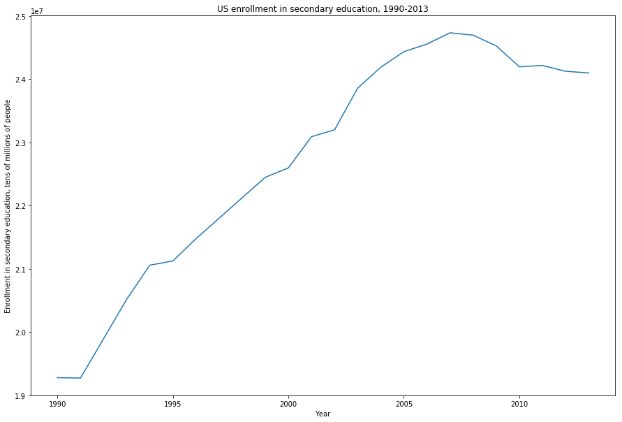

```python
plt.figure(figsize=(15,10))
plt.plot(stage2_exp_edu_usa['Year'].values, stage2_exp_edu_usa['SecEdEnrollment'])
plt.xlabel('Year')
plt.ylabel('Enrollment in secondary education, tens of millions of people')
plt.title('US enrollment in secondary education, 1990-2013')
plt.show()
```

Here, we see the same sort of dip in secondary education enrollment that we saw in the Chinese data.

This further supports the hypothesis that the global trend of families having less children in the 21st century is a confounding variable in this analysis which leads to less children going to secondary school overall. *This would be an interesting focus of future analysis.*

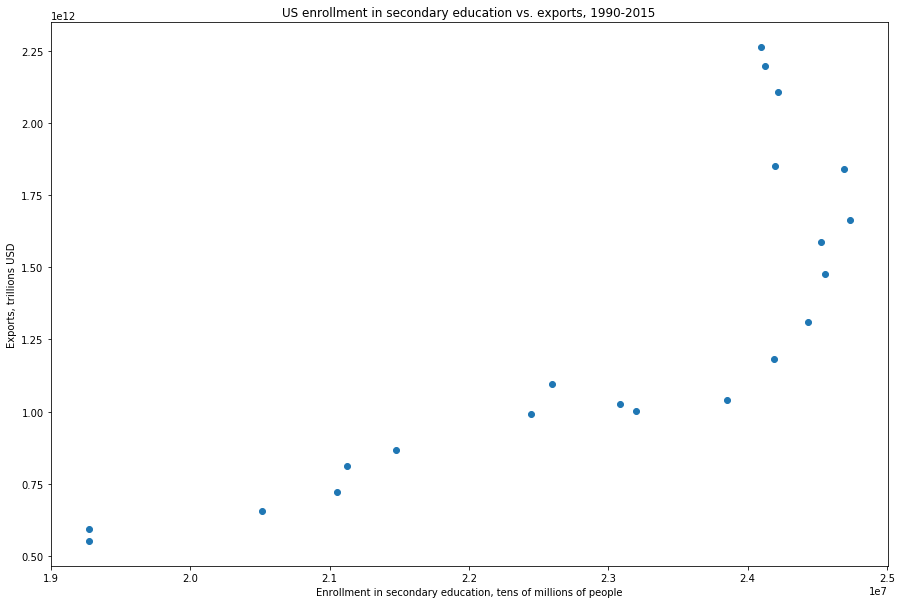

```python
plt.figure(figsize=(15,10))
plt.scatter(stage2_exp_edu_usa['SecEdEnrollment'].values, stage2_exp_edu_usa['Exports'].values)
plt.xlabel('Enrollment in secondary education, tens of millions of people')
plt.ylabel('Exports, trillions USD')
plt.title('US enrollment in secondary education vs. exports, 1990-2015')
plt.show()
```

```python
stage2_exp_edu_usa.corr()
```

|  | Year | SecEdEnrollment | Exports |
| --- | --- | --- | --- |
| Year | 1.000000 | 0.924851 | 0.956387 |
| SecEdEnrollment | 0.924851 | 1.000000 | 0.799794 |
| Exports | 0.956387 | 0.799794 | 1.000000 |

### Comparing Chinese and U.S. labor & education performance

Let's quickly compare how China and the U.S. compare in terms of labor and education, the two indicators we studied here.

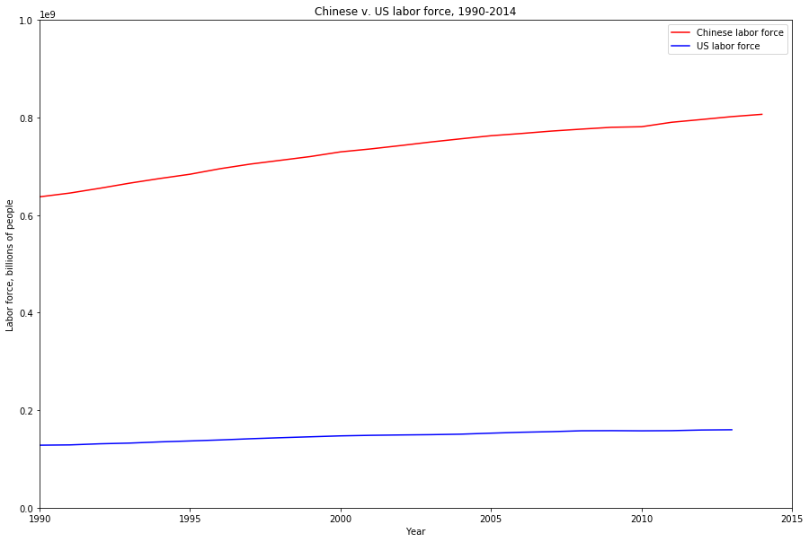

```python
plt.figure(figsize=(15,10))
plt.plot(stage2_exp_labor_chn['Year'].values, stage2_exp_labor_chn['LaborForce'], color='r')
plt.plot(stage2_exp_labor_usa['Year'].values, stage2_exp_labor_usa['LaborForce'], color='b')
plt.xlabel('Year')
plt.ylabel('Labor force, billions of people')
plt.title('Chinese v. US labor force, 1990-2014')
plt.legend(['Chinese labor force','US labor force'])
plt.axis([1990, 2015,0,10e8])
plt.show()
```

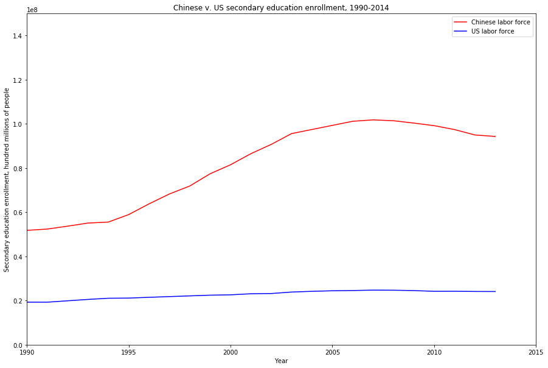

```python
plt.figure(figsize=(15,10))
plt.plot(stage2_exp_edu_chn['Year'].values, stage2_exp_edu_chn['SecEdEnrollment'], color='r')
plt.plot(stage2_exp_edu_usa['Year'].values, stage2_exp_edu_usa['SecEdEnrollment'], color='b')
plt.xlabel('Year')
plt.ylabel('Secondary education enrollment, hundred millions of people')
plt.title('Chinese v. US secondary education enrollment, 1990-2014')
plt.legend(['Chinese labor force','US labor force'])
plt.axis([1990, 2015,0,1.5e8])
plt.show()
```

Here we see the Chinese leading the US in both labor force and secondary education enrollment, both symptoms of a massively larger population size, and both pointing towards higher productivity.

**Thus, it is supported that China's exports have risen dramatically, contributing to that country's trade surplus, in contrast to the US's stagnating labor force & secondary education enrollment, which could have contributed to that country's trade deficit.**

### Chinese imports

What indicators are related to imports? We hypothesize that imports increase when a country becomes more consumerist, and two symptoms of a more consumerist society are higher **CO2 consumption** and **mobile cellular subscriptions**.

We repeat the process carried out for Chinese exports above.

#### CO2 emissions and Chinese imports

```python
indicators[indicators.str.contains('CO2')].head(5)
```

```
6                                    CO2 emissions (kt)
7                CO2 emissions (metric tons per capita)
8     CO2 emissions from gaseous fuel consumption (%...
9      CO2 emissions from gaseous fuel consumption (kt)
10    CO2 emissions from liquid fuel consumption (% ...
dtype: object
```

```python
ind_nrg_filter = stage0['IndicatorName'].str.match('CO2 emissions \(kt\)')
year_filter = stage0['Year'] >= 1990
stage3_imp_nrg = stage0[ind_nrg_filter & year_filter]
stage3_imp_nrg_chn = stage3_imp_nrg[stage3_imp_nrg['CountryCode'].str.match('CHN')]
stage3_imp_nrg_chn = stage3_imp_nrg_chn.merge(chn_data_imports, on=['CountryCode','Year'], how='inner')
stage3_imp_nrg_chn = stage3_imp_nrg_chn.drop(['IndicatorName_x','IndicatorName_y'], axis=1)
stage3_imp_nrg_chn.rename(columns={'Value_x':'CO2Emissions','Value_y':'Imports'}, inplace=True)
stage3_imp_nrg_chn.head(5)
```

|  | CountryCode | Year | CO2Emissions | Imports |
| --- | --- | --- | --- | --- |
| 0 | CHN | 1990 | 2460744.017 | 4.922180e+10 |
| 1 | CHN | 1991 | 2584538.270 | 5.921080e+10 |
| 2 | CHN | 1992 | 2695982.067 | 6.975353e+10 |
| 3 | CHN | 1993 | 2878694.009 | 7.462880e+10 |
| 4 | CHN | 1994 | 3058241.330 | 1.155638e+11 |

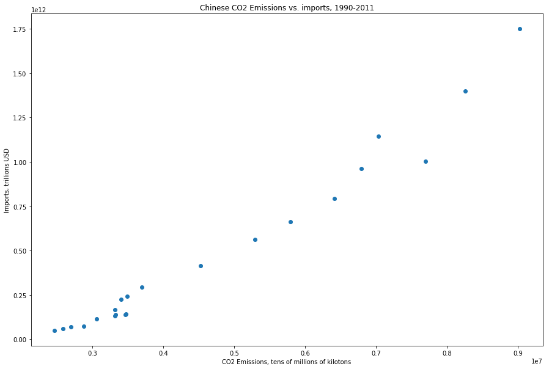

```python
plt.figure(figsize=(15,10))
plt.scatter(stage3_imp_nrg_chn['CO2Emissions'].values, stage3_imp_nrg_chn['Imports'].values)
plt.xlabel('CO2 Emissions, tens of millions of kilotons')
plt.ylabel('Imports, trillions USD')
plt.title('Chinese CO2 Emissions vs. imports, 1990-2011')
plt.show()
```

```python
stage3_imp_nrg_chn.corr()
```

|  | Year | CO2Emissions | Imports |
| --- | --- | --- | --- |
| Year | 1.000000 | 0.930368 | 0.898989 |
| CO2Emissions | 0.930368 | 1.000000 | 0.983977 |
| Imports | 0.898989 | 0.983977 | 1.000000 |

We see a **very strong (0.984) correlation** between CO2 emissions and imports, suggesting that the CO2 emissions brought about by higher consumerism relates to more imported goods.

#### Cell phone subscriptions and Chinese imports

```python
indicators[indicators.str.contains('cell')]
```

```
70                     Mobile cellular subscriptions
71    Mobile cellular subscriptions (per 100 people)
dtype: object
```

```python
ind_cell_filter = stage0['IndicatorName'].str.match('Mobile cellular subscriptions \(per 100 people\)')
year_filter = stage0['Year'] >= 1990
stage3_imp_cell = stage0[ind_cell_filter & year_filter]
stage3_imp_cell_chn = stage3_imp_cell[stage3_imp_cell['CountryCode'].str.match('CHN')]
stage3_imp_cell_chn = stage3_imp_cell_chn.merge(chn_data_imports, on=['CountryCode','Year'], how='inner')
stage3_imp_cell_chn = stage3_imp_cell_chn.drop(['IndicatorName_x','IndicatorName_y'], axis=1)
stage3_imp_cell_chn.rename(columns={'Value_x':'CellSubs','Value_y':'Imports'}, inplace=True)
stage3_imp_cell_chn.head(5)
```

|  | CountryCode | Year | CellSubs | Imports |
| --- | --- | --- | --- | --- |
| 0 | CHN | 1990 | 0.001572 | 4.922180e+10 |
| 1 | CHN | 1991 | 0.004019 | 5.921080e+10 |
| 2 | CHN | 1992 | 0.014759 | 6.975353e+10 |
| 3 | CHN | 1993 | 0.052592 | 7.462880e+10 |
| 4 | CHN | 1994 | 0.127904 | 1.155638e+11 |

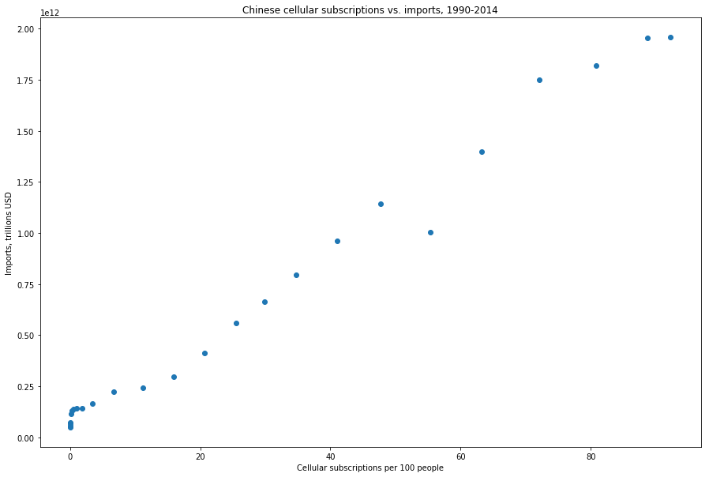

```python
plt.figure(figsize=(15,10))
plt.scatter(stage3_imp_cell_chn['CellSubs'].values, stage3_imp_cell_chn['Imports'].values)
plt.xlabel('Cellular subscriptions per 100 people')
plt.ylabel('Imports, trillions USD')
plt.title('Chinese cellular subscriptions vs. imports, 1990-2014')
plt.show()
```

```python
stage3_imp_cell_chn.corr()
```

|  | Year | CellSubs | Imports |
| --- | --- | --- | --- |
| Year | 1.000000 | 0.934900 | 0.921675 |
| CellSubs | 0.934900 | 1.000000 | 0.993709 |
| Imports | 0.921675 | 0.993709 | 1.000000 |

We see a very **strong positive correlation (0.994)** between cellular subscriptions per 100 people and imports, further suggesting a link between consumerism and imported goods. *Let's disregard the fact that many cell phones rely on parts manufactured in China!*

### US imports

#### CO2 emissions and US imports

```python
stage3_imp_nrg_usa = stage3_imp_nrg[stage3_imp_nrg['CountryCode'].str.match('USA')]
stage3_imp_nrg_usa = stage3_imp_nrg_usa.merge(usa_data_imports, on=['CountryCode','Year'], how='inner')
stage3_imp_nrg_usa = stage3_imp_nrg_usa.drop(['IndicatorName_x','IndicatorName_y'], axis=1)
stage3_imp_nrg_usa.rename(columns={'Value_x':'CO2Emissions','Value_y':'Imports'}, inplace=True)
stage3_imp_nrg_usa.head(5)
```

|  | CountryCode | Year | CO2Emissions | Imports |
| --- | --- | --- | --- | --- |
| 0 | USA | 1990 | 4823557.132 | 6.297290e+11 |
| 1 | USA | 1991 | 4822383.692 | 6.235470e+11 |
| 2 | USA | 1992 | 4911103.090 | 6.677930e+11 |
| 3 | USA | 1993 | 5032931.831 | 7.199740e+11 |
| 4 | USA | 1994 | 5098475.789 | 8.134250e+11 |

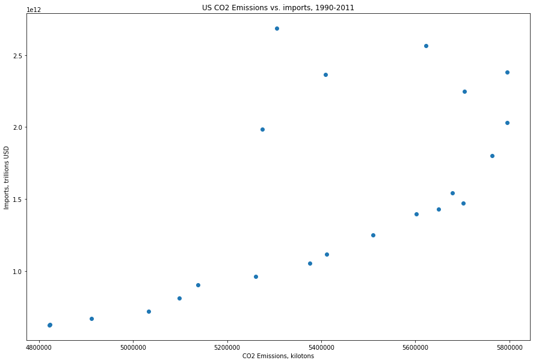

```python
plt.figure(figsize=(15,10))
plt.scatter(stage3_imp_nrg_usa['CO2Emissions'].values, stage3_imp_nrg_usa['Imports'].values)
plt.xlabel('CO2 Emissions, kilotons')
plt.ylabel('Imports, trillions USD')
plt.title('US CO2 Emissions vs. imports, 1990-2011')
plt.show()
```

```python
stage3_imp_nrg_usa.corr()
```

|  | Year | CO2Emissions | Imports |
| --- | --- | --- | --- |
| Year | 1.00000 | 0.702070 | 0.970500 |
| CO2Emissions | 0.70207 | 1.000000 | 0.676845 |
| Imports | 0.97050 | 0.676845 | 1.000000 |

We see a **weak positive correlation (0.677)** between CO2 emissions and imports. Note that this is much weaker than that of China.

```python
stage3_imp_cell_usa = stage3_imp_cell[stage3_imp_cell['CountryCode'].str.match('USA')]
stage3_imp_cell_usa = stage3_imp_cell_usa.merge(usa_data_imports, on=['CountryCode','Year'], how='inner')
stage3_imp_cell_usa = stage3_imp_cell_usa.drop(['IndicatorName_x','IndicatorName_y'], axis=1)
stage3_imp_cell_usa.rename(columns={'Value_x':'CellSubs','Value_y':'Imports'}, inplace=True)
stage3_imp_cell_usa.head(5)
```

|  | CountryCode | Year | CellSubs | Imports |
| --- | --- | --- | --- | --- |
| 0 | USA | 1990 | 2.075802 | 6.297290e+11 |
| 1 | USA | 1991 | 2.939644 | 6.235470e+11 |
| 2 | USA | 1992 | 4.249049 | 6.677930e+11 |
| 3 | USA | 1993 | 6.103717 | 7.199740e+11 |
| 4 | USA | 1994 | 9.104921 | 8.134250e+11 |

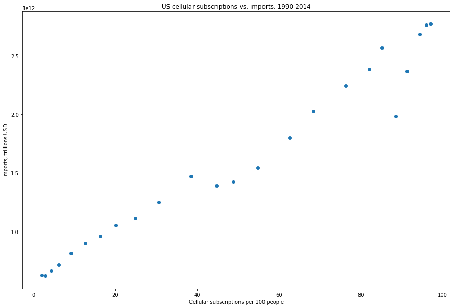

```python
plt.figure(figsize=(15,10))
plt.scatter(stage3_imp_cell_usa['CellSubs'].values, stage3_imp_cell_usa['Imports'].values)
plt.xlabel('Cellular subscriptions per 100 people')
plt.ylabel('Imports, trillions USD')
plt.title('US cellular subscriptions vs. imports, 1990-2014')
plt.show()
```

```python
stage3_imp_cell_usa.corr()
```

|  | Year | CellSubs | Imports |
| --- | --- | --- | --- |
| Year | 1.000000 | 0.990659 | 0.977172 |
| CellSubs | 0.990659 | 1.000000 | 0.981945 |
| Imports | 0.977172 | 0.981945 | 1.000000 |

We see a **strong positive correlation (0.982)** between cellular subscriptions per 100 people and imports.

### Comparing Chinese and US CO2 emissions and cell phone subscriptions

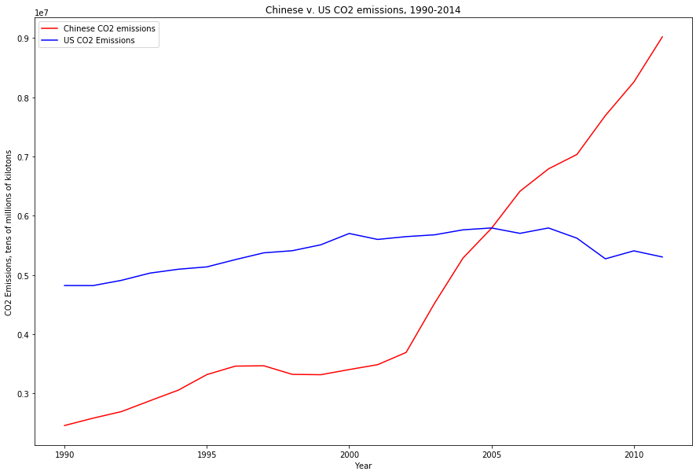

```python
plt.figure(figsize=(15,10))
plt.plot(stage3_imp_nrg_chn['Year'].values, stage3_imp_nrg_chn['CO2Emissions'], color='r')
plt.plot(stage3_imp_nrg_usa['Year'].values, stage3_imp_nrg_usa['CO2Emissions'], color='b')
plt.xlabel('Year')
plt.ylabel('CO2 Emissions, tens of millions of kilotons')
plt.title('Chinese v. US CO2 emissions, 1990-2014')
plt.legend(['Chinese CO2 emissions','US CO2 Emissions'])
plt.show()
```

Interestingly, we see the Chinese CO2 emissions skyrocket in the early 2000s, surpassing the stagnating US emissions in 2005.

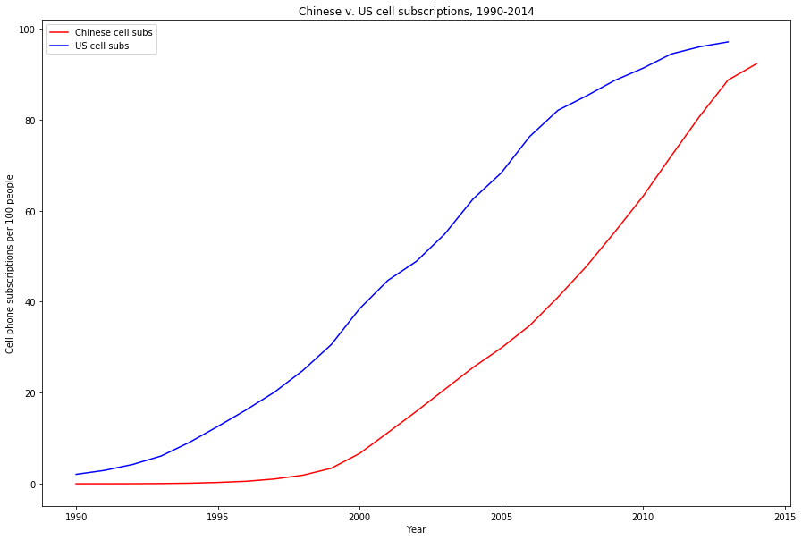

```python
plt.figure(figsize=(15,10))
plt.plot(stage3_imp_cell_chn['Year'].values, stage3_imp_cell_chn['CellSubs'], color='r')
plt.plot(stage3_imp_cell_usa['Year'].values, stage3_imp_cell_usa['CellSubs'], color='b')
plt.xlabel('Year')
plt.ylabel('Cell phone subscriptions per 100 people')
plt.title('Chinese v. US cell subscriptions, 1990-2014')
plt.legend(['Chinese cell subs','US cell subs'])
plt.show()
```

Both the US and China's cell subscriptions have grown at similar rates, with the US still edging out China by a small margin. But both countries are near 100 percent of people having cell phone subscriptions, so this information is not too useful at the moment.

Altogether, **it is not supported** that an increase in consumerism via higher CO2 emissions and cellular subscriptions can properly explain the Americans' higher levels of imports or the American trade deficit.

This is especially true of CO2 emissions. The US's lower CO2 emission level than that of China (again, probably attributed to China's larger population) did not correlate strongly with higher imports, which contributed to the US's trade deficit. Conversely, higher CO2 emissions in China did strongly correlate with higher levels of imports, but China's trade surplus still stands. In fact, these results seem counterintuitive to the fact that China is in surplus but the US is in deficit.

**This analysis on imports was not conclusive as to why the US is at a deficit and China is at a surplus.**

Altogether, while our indicators gave varying levels of support to answering why the US and China have such different trade levels, it is important to note that these correlations are undoubtedly related to rising populations. Let's look briefly at these population levels.

```python
indicators[indicators.str.contains('Population')]
```

```
92             Population ages 65 and above (% of total)
93                          Population growth (annual %)
94                            Population in largest city
95     Population in the largest city (% of urban pop...
96     Population in urban agglomerations of more tha...
97     Population in urban agglomerations of more tha...
98                    Population, ages 0-14 (% of total)
99                   Population, ages 15-64 (% of total)
100                      Population, female (% of total)
101                                    Population, total
279    Population density (people per sq. km of land ...
867    Population living in areas where elevation is ...
dtype: object
```

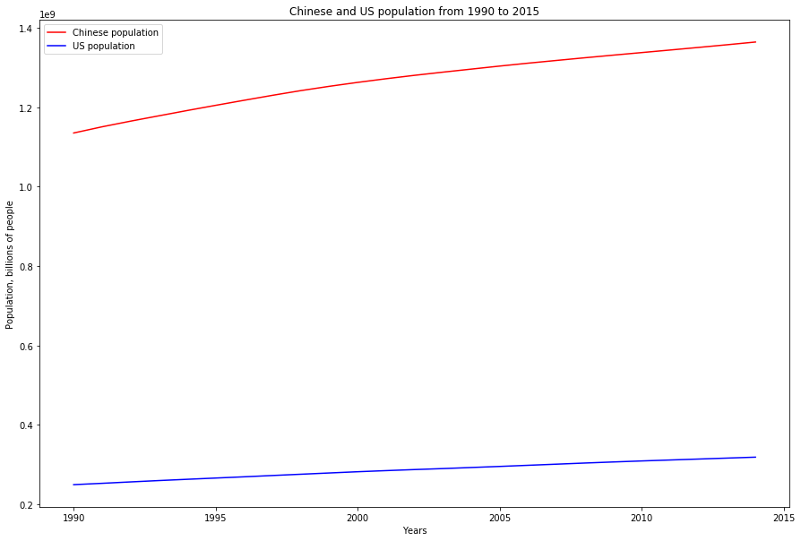

```python
ind_pop_filter = stage0['IndicatorName'].str.match('Population, total')
year_filter = stage0['Year'] >= 1990
stage3_pop = stage0[ind_pop_filter & year_filter]

stage3_pop_chn = stage3_pop[stage3_pop['CountryCode'].str.match('CHN')]
stage3_pop_usa = stage3_pop[stage3_pop['CountryCode'].str.match('USA')]

plt.figure(figsize=(15,10))
plt.plot(stage3_pop_chn['Year'].values, stage3_pop_chn['Value'].values, color='r')
plt.plot(stage3_pop_usa['Year'].values, stage3_pop_usa['Value'].values, color='b')
plt.xlabel("Years")
plt.ylabel("Population, billions of people")
plt.title("Chinese and US population from 1990 to 2015")
plt.legend(['Chinese population','US population'])
plt.show()
```

### The US and China in a global trade economy

What about the rest of the world? How do the US and China compare? For this, we return to the `stage1` DataFrame set up before which had country code, imports/exports, year, and value.

First, let's set up a "Net Trade" column.

```python
stage1_exports = stage1[stage1['IndicatorName'].str.contains('Exports')]
stage1_imports = stage1[stage1['IndicatorName'].str.contains('Imports')]
stage1_netTrade = stage1_exports.merge(stage1_imports, on=['CountryCode', 'Year'], how='inner')
stage1_netTrade = stage1_netTrade.drop(['IndicatorName_x','IndicatorName_y'], axis=1)
stage1_netTrade.rename(columns={'Value_x':'Exports','Value_y':'Imports'}, inplace=True)
stage1_netTrade['NetTrade'] = stage1_netTrade['Exports'].values - stage1_netTrade['Imports'].values
stage1_netTrade.head(5)
```

|  | CountryCode | Year | Exports | Imports | NetTrade |
| --- | --- | --- | --- | --- | --- |
| 0 | ALB | 1990 | 3.125000e+08 | 4.875000e+08 | -1.750000e+08 |
| 1 | DZA | 1990 | 1.454566e+10 | 1.547220e+10 | -9.265465e+08 |
| 2 | AGO | 1990 | 3.342246e+09 | 3.342246e+09 | 0.000000e+00 |
| 3 | ATG | 1990 | 3.483111e+08 | 3.405593e+08 | 7.751852e+06 |
| 4 | ARG | 1990 | 1.464345e+10 | 6.546484e+09 | 8.096966e+09 |

The following also gives us the net exports, imports, overall net trade, and share of total exports and imports by year.

```python
stage1_netExports_yr = stage1_netTrade[['Year','Exports']].groupby('Year').sum()
stage1_netImports_yr = stage1_netTrade[['Year','Imports']].groupby('Year').sum()
stage1_netTrade_yr = stage1_netTrade[['Year','NetTrade']].groupby('Year').sum()

stage1_netTrade = stage1_netTrade.merge(stage1_netExports_yr, on='Year', how='inner')
stage1_netTrade.rename(columns={'Exports_x':'Exports','Exports_y':'TotalExports_Yr'}, inplace=True)
stage1_netTrade = stage1_netTrade.merge(stage1_netImports_yr, on='Year', how='inner')
stage1_netTrade.rename(columns={'Imports_x':'Imports','Imports_y':'TotalImports_Yr'}, inplace=True)
stage1_netTrade['ExportsShare'] = stage1_netTrade['Exports'].values / stage1_netTrade['TotalExports_Yr'].values
stage1_netTrade['ImportsShare'] = stage1_netTrade['Imports'].values / stage1_netTrade['TotalImports_Yr'].values
stage1_netTrade.head(5)
```

|  | CountryCode | Year | Exports | Imports | NetTrade | TotalExports_Yr | TotalImports_Yr | ExportsShare | ImportsShare |
| --- | --- | --- | --- | --- | --- | --- | --- | --- | --- |
| 0 | ALB | 1990 | 3.125000e+08 | 4.875000e+08 | -1.750000e+08 | 4.151695e+12 | 4.234862e+12 | 0.000075 | 0.000115 |
| 1 | DZA | 1990 | 1.454566e+10 | 1.547220e+10 | -9.265465e+08 | 4.151695e+12 | 4.234862e+12 | 0.003504 | 0.003654 |
| 2 | AGO | 1990 | 3.342246e+09 | 3.342246e+09 | 0.000000e+00 | 4.151695e+12 | 4.234862e+12 | 0.000805 | 0.000789 |
| 3 | ATG | 1990 | 3.483111e+08 | 3.405593e+08 | 7.751852e+06 | 4.151695e+12 | 4.234862e+12 | 0.000084 | 0.000080 |
| 4 | ARG | 1990 | 1.464345e+10 | 6.546484e+09 | 8.096966e+09 | 4.151695e+12 | 4.234862e+12 | 0.003527 | 0.001546 |

#### The world's trade in 2013

Let's focus on the most recent year for which both the US and China had trade data, which happened to be 2013.

```python
stage1_netTrade_2013 = stage1_netTrade[stage1_netTrade['Year'] == 2013]
stage1_netTrade_2013.head()
```

|  | CountryCode | Year | Exports | Imports | NetTrade | TotalExports_Yr | TotalImports_Yr | ExportsShare | ImportsShare |
| --- | --- | --- | --- | --- | --- | --- | --- | --- | --- |
| 4035 | AFG | 2013 | 1.290528e+09 | 1.017991e+10 | -8.889384e+09 | 2.257984e+13 | 2.189028e+13 | 0.000057 | 0.000465 |
| 4036 | ALB | 2013 | 4.530755e+09 | 6.835365e+09 | -2.304610e+09 | 2.257984e+13 | 2.189028e+13 | 0.000201 | 0.000312 |
| 4037 | DZA | 2013 | 6.965942e+10 | 6.376746e+10 | 5.891960e+09 | 2.257984e+13 | 2.189028e+13 | 0.003085 | 0.002913 |
| 4038 | AGO | 2013 | 7.010319e+10 | 4.981981e+10 | 2.028338e+10 | 2.257984e+13 | 2.189028e+13 | 0.003105 | 0.002276 |
| 4039 | ATG | 2013 | 5.498171e+08 | 7.207880e+08 | -1.709709e+08 | 2.257984e+13 | 2.189028e+13 | 0.000024 | 0.000033 |

It is not too useful to look at a histogram of the frequency of the net export shares.

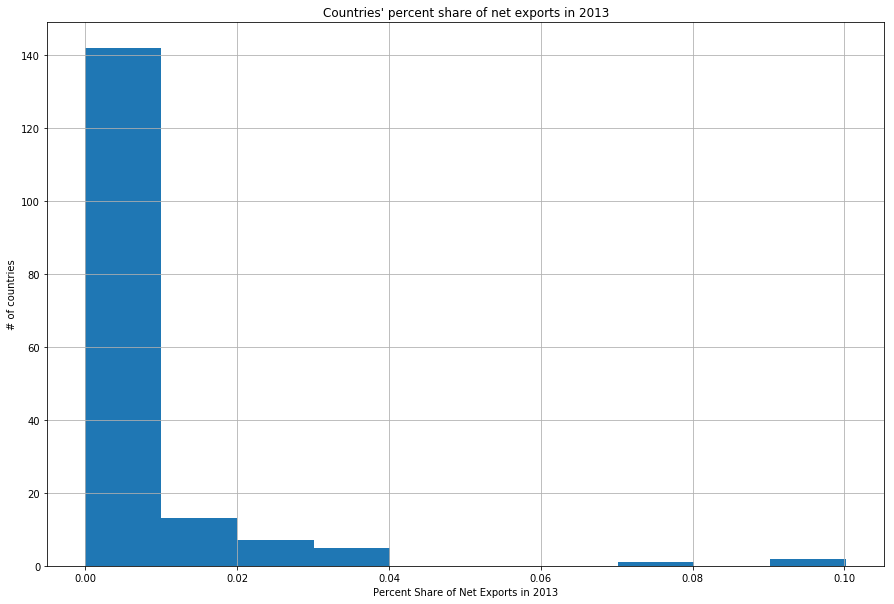

```python
plt.figure(figsize=(15,10))
plt.hist(stage1_netTrade_2013['ExportsShare'].values, 10, density=False)
plt.xlabel("Percent Share of Net Exports in 2013")
plt.ylabel("# of countries")
plt.title('Countries\' percent share of net exports in 2013')
plt.grid(True)
plt.show()
```

All we see is that most countries have a tiny share of the net exports, and far fewer countries have larger shares.

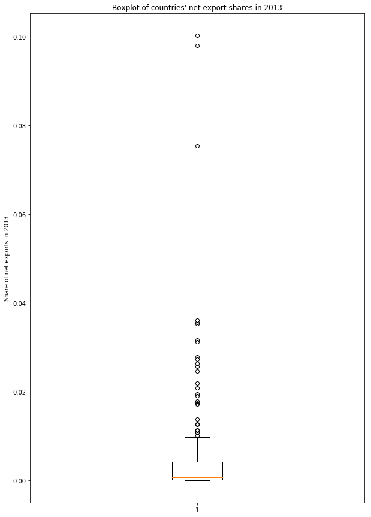

```python
plt.figure(figsize=(10,15))
plt.boxplot(stage1_netTrade_2013['ExportsShare'])
plt.ylabel('Share of net exports in 2013')
plt.title('Boxplot of countries\' net export shares in 2013')
plt.show()
```

This also isn't too helpful. We already knew that most data was in the lowest percentile range, and the few large-shared countries would be outliers.

Although a bar chart yields a huge graphic, it can be useful in looking at the world's top exporters and importers.

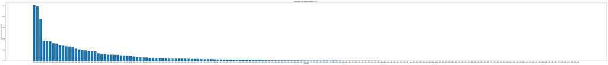

```python
stage1_netTrade_2013_sorted_exp = stage1_netTrade_2013.sort_values(by='ExportsShare', ascending=False)
plt.figure(figsize=(100,10))
plt.bar(stage1_netTrade_2013_sorted_exp['CountryCode'],stage1_netTrade_2013_sorted_exp['ExportsShare'])
plt.xlabel('Countries')
plt.ylabel('Share of net exports in 2013')
plt.title('Countries\' net export shares in 2013')
plt.show()
```

We see the US in first, followed closely by China. The two countries lead the world in exports.

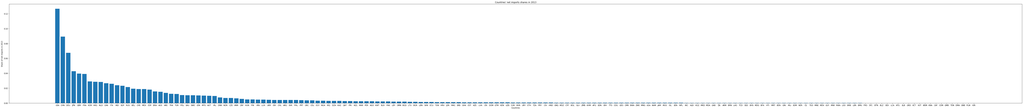

```python
stage1_netTrade_2013_sorted_imp = stage1_netTrade_2013.sort_values(by='ImportsShare', ascending=False)
plt.figure(figsize=(100,10))
plt.bar(stage1_netTrade_2013_sorted_imp['CountryCode'],stage1_netTrade_2013_sorted_imp['ImportsShare'])
plt.xlabel('Countries')
plt.ylabel('Share of net imports in 2013')
plt.title('Countries\' net imports shares in 2013')
plt.show()
```

We see the US in first, followed again by China, but not as closely. The two countries lead the world in imports, but the US leads in imports more strongly. This supports our knowledge of the US's large trade deficit.

Let's look at net trade.

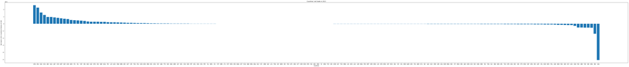

```python
stage1_netTrade_2013_sorted_net = stage1_netTrade_2013.sort_values(by='NetTrade', ascending=False)
plt.figure(figsize=(100,10))
plt.bar(stage1_netTrade_2013_sorted_net['CountryCode'],stage1_netTrade_2013_sorted_net['NetTrade'])
plt.xlabel('Countries')
plt.ylabel('Net trade in 2013, hundred of billions of USD')
plt.title('Countries\' net trade in 2013')
plt.show()
```

In this dramatic bar chart, we see China leading the world's net trade with the highest trade surplus, and the US on the opposite end leading the world with the highest trade deficit.

The preceding three bar charts illustrate the power of the US and Chinese economies. The two countries lead the world in both exports and imports, and all countries fall somewhere in between the two in terms of net trade.

We wish to visualize this global trade situation in a more compelling way. Let's use the package `folium` and a set of world coordinates to accomplish this.

```python
import folium
country_geo = './world-countries.json'
map = folium.Map(location=[50,0], zoom_start=1.4)
folium.Choropleth(geo_data=country_geo, data=stage1_netTrade_2013,
              columns=['CountryCode','NetTrade'],
              fill_color='PiYG', nan_fill_color='bdbdbd',
                  key_on='feature.id', fill_opacity=0.7, line_opacity=0.2).add_to(map)
map.save('plot_data.html')
from IPython.display import HTML
HTML('<iframe src=plot_data.html width=700 height=450></iframe>')
```

[interactive chart not shown]

This simple interactive map shows countries in deficit in red and countries in surplus in green. Countries wihtout data are marked in dark grey.

Here, you can see how the US and China stack up to the rest of the world.

Altogether, this analysis shows that the US and China hold important positions in terms of international trade.

## Conclusion and Further Directions

In this analysis, we compared exports and imports in the US and China's trade economies. Then, we explored some possible correlating factors such as labor force population and CO2 emissions, ultimately giving us an idea of why China's exports are higher, but not supporting our inquiry about why the US's imports are higher. Finally, we saw how the world at large is situated amongst the US and China's two supereconomies, further suggesting the importance of the ongoing trade war between the two countries.

Where might China and the US's deficits go from here? Economists and statisticians alike would both scoff at what is presented below: linear regression of previous net trade of both countries. We make use of the sci-kit learn package.

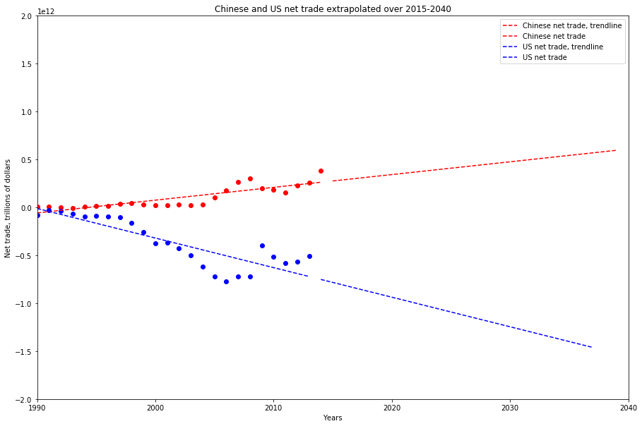

```python
stage1_netTrade_chn = stage1_netTrade[stage1_netTrade['CountryCode'].str.match('CHN')]
stage1_netTrade_usa = stage1_netTrade[stage1_netTrade['CountryCode'].str.match('USA')]

from sklearn.linear_model import LinearRegression

model_chn = LinearRegression()
model_chn.fit(stage1_netTrade_chn['Year'].values[:,np.newaxis], stage1_netTrade_chn['NetTrade'].values)

model_usa = LinearRegression()
model_usa.fit(stage1_netTrade_usa['Year'].values[:,np.newaxis], stage1_netTrade_usa['NetTrade'].values)

years_set_chn = stage1_netTrade_chn['Year'].values[:,np.newaxis]
years_set_usa = stage1_netTrade_usa['Year'].values[:,np.newaxis]

years_set_chn2 = pd.Series(range(2015,2040))[:,np.newaxis]
years_set_usa2 = pd.Series(range(2014,2038))[:,np.newaxis]

plt.figure(figsize=(15,10))
plt.scatter(stage1_netTrade_chn['Year'].values, stage1_netTrade_chn['NetTrade'].values, color='r')
plt.plot(years_set_chn.tolist(), model_chn.predict(years_set_chn), color='r', ls='dashed')
plt.plot(range(2015,2040), model_chn.predict(years_set_chn2), color='r', ls='dashed')
plt.scatter(stage1_netTrade_usa['Year'].values, stage1_netTrade_usa['NetTrade'].values, color='b')
plt.plot(range(2014,2038), model_usa.predict(years_set_usa2), color='b', ls='dashed')
plt.plot(years_set_usa.tolist(), model_usa.predict(years_set_usa), color='b', ls='dashed')
plt.xlabel("Years")
plt.ylabel("Net trade, trillions of dollars")
plt.title("Chinese and US net trade extrapolated over 2015-2040")
plt.legend(['Chinese net trade, trendline','Chinese net trade','US net trade, trendline','US net trade'])
plt.axis([1990, 2040, -2e12, 2e12])
plt.show()
```

Although other regression models would have been more elegant, this graph at least shows the divergence between China's trade surplus and the US's trade deficit. It also shows the gap widening to what is potentially an over 2 trillion USD gap by 2040.

In conclusion, the US-Chinese trade war is important to the modern international trade system, and whatever happens will have intense global ramifications.

Future analytics could explore:

1. Other economic indicators which are predictors of imports and exports
2. Visualizing the history of the global trade economy with an interactive map to see trends in rising economies
3. Using more elegant regression techniques to predict the future of the US-China trade imbalance.